# Exploratory Data Analysis and Visualization- Group 3

🔷 IMPORT LIBRARIES

```python
import pandas as pd
import matplotlib.pyplot as plt
import seaborn as sns
```

## 1 🔷 PART A: LOADING AND UNDERSTANDING THE DATA

### Load dataset

```python
df = pd.read_csv(r"C:\Users\Mancoba\Downloads\2019.csv")
df
```

|  | Overall rank | Country or region | Score | GDP per capita | Social support | Healthy life expectancy | Freedom to make life choices | Generosity | Perceptions of corruption |
| --- | --- | --- | --- | --- | --- | --- | --- | --- | --- |
| 0 | 1 | Finland | 7.769 | 1.340 | 1.587 | 0.986 | 0.596 | 0.153 | 0.393 |
| 1 | 2 | Denmark | 7.600 | 1.383 | 1.573 | 0.996 | 0.592 | 0.252 | 0.410 |
| 2 | 3 | Norway | 7.554 | 1.488 | 1.582 | 1.028 | 0.603 | 0.271 | 0.341 |
| 3 | 4 | Iceland | 7.494 | 1.380 | 1.624 | 1.026 | 0.591 | 0.354 | 0.118 |
| 4 | 5 | Netherlands | 7.488 | 1.396 | 1.522 | 0.999 | 0.557 | 0.322 | 0.298 |
| ... | ... | ... | ... | ... | ... | ... | ... | ... | ... |
| 151 | 152 | Rwanda | 3.334 | 0.359 | 0.711 | 0.614 | 0.555 | 0.217 | 0.411 |
| 152 | 153 | Tanzania | 3.231 | 0.476 | 0.885 | 0.499 | 0.417 | 0.276 | 0.147 |
| 153 | 154 | Afghanistan | 3.203 | 0.350 | 0.517 | 0.361 | 0.000 | 0.158 | 0.025 |
| 154 | 155 | Central African Republic | 3.083 | 0.026 | 0.000 | 0.105 | 0.225 | 0.235 | 0.035 |
| 155 | 156 | South Sudan | 2.853 | 0.306 | 0.575 | 0.295 | 0.010 | 0.202 | 0.091 |

156 rows × 9 columns

## displays the first 10 rows

```python
df.head(10)
```

|  | Overall rank | Country or region | Score | GDP per capita | Social support | Healthy life expectancy | Freedom to make life choices | Generosity | Perceptions of corruption |
| --- | --- | --- | --- | --- | --- | --- | --- | --- | --- |
| 0 | 1 | Finland | 7.769 | 1.340 | 1.587 | 0.986 | 0.596 | 0.153 | 0.393 |
| 1 | 2 | Denmark | 7.600 | 1.383 | 1.573 | 0.996 | 0.592 | 0.252 | 0.410 |
| 2 | 3 | Norway | 7.554 | 1.488 | 1.582 | 1.028 | 0.603 | 0.271 | 0.341 |
| 3 | 4 | Iceland | 7.494 | 1.380 | 1.624 | 1.026 | 0.591 | 0.354 | 0.118 |
| 4 | 5 | Netherlands | 7.488 | 1.396 | 1.522 | 0.999 | 0.557 | 0.322 | 0.298 |
| 5 | 6 | Switzerland | 7.480 | 1.452 | 1.526 | 1.052 | 0.572 | 0.263 | 0.343 |
| 6 | 7 | Sweden | 7.343 | 1.387 | 1.487 | 1.009 | 0.574 | 0.267 | 0.373 |
| 7 | 8 | New Zealand | 7.307 | 1.303 | 1.557 | 1.026 | 0.585 | 0.330 | 0.380 |
| 8 | 9 | Canada | 7.278 | 1.365 | 1.505 | 1.039 | 0.584 | 0.285 | 0.308 |
| 9 | 10 | Austria | 7.246 | 1.376 | 1.475 | 1.016 | 0.532 | 0.244 | 0.226 |

displays the last 10 rows

```python
df.tail(10)
```

|  | Overall rank | Country or region | Score | GDP per capita | Social support | Healthy life expectancy | Freedom to make life choices | Generosity | Perceptions of corruption |
| --- | --- | --- | --- | --- | --- | --- | --- | --- | --- |
| 146 | 147 | Haiti | 3.597 | 0.323 | 0.688 | 0.449 | 0.026 | 0.419 | 0.110 |
| 147 | 148 | Botswana | 3.488 | 1.041 | 1.145 | 0.538 | 0.455 | 0.025 | 0.100 |
| 148 | 149 | Syria | 3.462 | 0.619 | 0.378 | 0.440 | 0.013 | 0.331 | 0.141 |
| 149 | 150 | Malawi | 3.410 | 0.191 | 0.560 | 0.495 | 0.443 | 0.218 | 0.089 |
| 150 | 151 | Yemen | 3.380 | 0.287 | 1.163 | 0.463 | 0.143 | 0.108 | 0.077 |
| 151 | 152 | Rwanda | 3.334 | 0.359 | 0.711 | 0.614 | 0.555 | 0.217 | 0.411 |
| 152 | 153 | Tanzania | 3.231 | 0.476 | 0.885 | 0.499 | 0.417 | 0.276 | 0.147 |
| 153 | 154 | Afghanistan | 3.203 | 0.350 | 0.517 | 0.361 | 0.000 | 0.158 | 0.025 |
| 154 | 155 | Central African Republic | 3.083 | 0.026 | 0.000 | 0.105 | 0.225 | 0.235 | 0.035 |
| 155 | 156 | South Sudan | 2.853 | 0.306 | 0.575 | 0.295 | 0.010 | 0.202 | 0.091 |

## displays the shape of the dataset

```python
df.shape
```

```
(156, 9)
```

### displays the columns of the dataset

```python
df.columns
```

```
Index(['Overall rank', 'Country or region', 'Score', 'GDP per capita',
       'Social support', 'Healthy life expectancy',
       'Freedom to make life choices', 'Generosity',
       'Perceptions of corruption'],
      dtype='object')
```

### Displays the data types

```python
df.dtypes
```

```
Overall rank                      int64
Country or region                object
Score                           float64
GDP per capita                  float64
Social support                  float64
Healthy life expectancy         float64
Freedom to make life choices    float64
Generosity                      float64
Perceptions of corruption       float64
dtype: object
```

### QUESTION4

### a) How many rows and columns are in the dataset?

The dataset contains **156 rows and 9 columns**.  
Rows represent countries, while columns represent variables.

### b) Which variables are numerical?

The numerical variables are:

- Overall rank
- Score
- GDP per capita
- Social support
- Healthy life expectancy
- Freedom to make life choices
- Generosity
- Perceptions of corruption

### c) Which variables are categorical?

The categorical variable is:

- Country or region

## 2 🔷 PART B: DATA CLEANING

### Checking for missing values in each columns

```python
5#
df.isnull().sum()
```

```
Overall rank                    0
Country or region               0
Score                           0
GDP per capita                  0
Social support                  0
Healthy life expectancy         0
Freedom to make life choices    0
Generosity                      0
Perceptions of corruption       0
dtype: int64
```

### Remove rows containing missing values

```python
6#
df_cleaned = df.dropna()
```

```python
print(f"Rows before removal: {len(df)}")
print(f"Rows after removal: {len(df_cleaned)}")
print(f"Rows removed: {len(df) - len(df_cleaned)}")
```

```
Rows before removal: 156
Rows after removal: 156
Rows removed: 0
```

### Checking for duplicate rows in the dataset.

```python
#7)
duplicate_count = df_cleaned.duplicated().sum()
print(f"Number of duplicate rows: {duplicate_count}")
```

```
Number of duplicate rows: 0
```

### Remove duplicate rows if any exist.

```python
#8
df_cleaned = df_cleaned.drop_duplicates()

print(f"Rows after removing duplicates: {len(df_cleaned)}")
```

```
Rows after removing duplicates: 156
```

### . Displaying the new shape of the cleaned dataset

```python
#9
df_cleaned.shape
```

```
(156, 9)
```

#### 10 Commentary

##### - a) No missing values were found

##### - b) A total of 0 rows were removed.

##### - c) No duplicates were found

## 3 🔷 PART C: RENAMING & SELECTION

### Rename columns

```python
#11
df_cleaned.rename(columns={
    'Country or region': 'country',
    'Score': 'happinessScore',
    'GDP per capita': 'gdpPerCapita',
    'Healthy life expectancy': 'health',
    'Freedom to make life choices': 'freedom'
}, inplace=True)

df_subset = df_cleaned[['country', 'happinessScore', 'gdpPerCapita', 'health', 'freedom']]

df_subset.head()
```

|  | country | happinessScore | gdpPerCapita | health | freedom |
| --- | --- | --- | --- | --- | --- |
| 0 | Finland | 7.769 | 1.340 | 0.986 | 0.596 |
| 1 | Denmark | 7.600 | 1.383 | 0.996 | 0.592 |
| 2 | Norway | 7.554 | 1.488 | 1.028 | 0.603 |
| 3 | Iceland | 7.494 | 1.380 | 1.026 | 0.591 |
| 4 | Netherlands | 7.488 | 1.396 | 0.999 | 0.557 |

##### QUESTION 13

##### REDUCES COMPLEXITY- Working with fewer variables makes the dataset easier to understand and analyze, especially when dealing with large data.

##### IMPROVES DATA VISUALISATION - Graphs and charts become clearer and more meaningful when they include only key variables.

##### IT SPEEDS UP ANALYSIS - Less data means faster computations and easier processing.

##### IT HELPS TO DETECT PTTERNS - It becomes easier to spot trends, relationships, and outliers when irrelevant variables are removed.

## 4 🔷 PART D: SORTING

### Sorting by happiness in descending order

```python
#14
df_sorted_by_score = df_subset.sort_values(by='happinessScore', ascending=False)
df_sorted_by_score
```

|  | country | happinessScore | gdpPerCapita | health | freedom |
| --- | --- | --- | --- | --- | --- |
| 0 | Finland | 7.769 | 1.340 | 0.986 | 0.596 |
| 1 | Denmark | 7.600 | 1.383 | 0.996 | 0.592 |
| 2 | Norway | 7.554 | 1.488 | 1.028 | 0.603 |
| 3 | Iceland | 7.494 | 1.380 | 1.026 | 0.591 |
| 4 | Netherlands | 7.488 | 1.396 | 0.999 | 0.557 |
| ... | ... | ... | ... | ... | ... |
| 151 | Rwanda | 3.334 | 0.359 | 0.614 | 0.555 |
| 152 | Tanzania | 3.231 | 0.476 | 0.499 | 0.417 |
| 153 | Afghanistan | 3.203 | 0.350 | 0.361 | 0.000 |
| 154 | Central African Republic | 3.083 | 0.026 | 0.105 | 0.225 |
| 155 | South Sudan | 2.853 | 0.306 | 0.295 | 0.010 |

156 rows × 5 columns

### Sort by GDP in descending order

```python
#15)
gdp_sorted = df_subset.sort_values(by='gdpPerCapita', ascending=False)
gdp_sorted
```

|  | country | happinessScore | gdpPerCapita | health | freedom |
| --- | --- | --- | --- | --- | --- |
| 28 | Qatar | 6.374 | 1.684 | 0.871 | 0.555 |
| 13 | Luxembourg | 7.090 | 1.609 | 1.012 | 0.526 |
| 33 | Singapore | 6.262 | 1.572 | 1.141 | 0.556 |
| 20 | United Arab Emirates | 6.825 | 1.503 | 0.825 | 0.598 |
| 50 | Kuwait | 6.021 | 1.500 | 0.808 | 0.493 |
| ... | ... | ... | ... | ... | ... |
| 126 | Congo (Kinshasa) | 4.418 | 0.094 | 0.357 | 0.269 |
| 140 | Liberia | 3.975 | 0.073 | 0.443 | 0.370 |
| 144 | Burundi | 3.775 | 0.046 | 0.380 | 0.220 |
| 154 | Central African Republic | 3.083 | 0.026 | 0.105 | 0.225 |
| 111 | Somalia | 4.668 | 0.000 | 0.268 | 0.559 |

156 rows × 5 columns

### Displaying the top 10 rows after each sorting operation

```python
#16)
df_sorted_by_score.head(10)
```

|  | country | happinessScore | gdpPerCapita | health | freedom |
| --- | --- | --- | --- | --- | --- |
| 0 | Finland | 7.769 | 1.340 | 0.986 | 0.596 |
| 1 | Denmark | 7.600 | 1.383 | 0.996 | 0.592 |
| 2 | Norway | 7.554 | 1.488 | 1.028 | 0.603 |
| 3 | Iceland | 7.494 | 1.380 | 1.026 | 0.591 |
| 4 | Netherlands | 7.488 | 1.396 | 0.999 | 0.557 |
| 5 | Switzerland | 7.480 | 1.452 | 1.052 | 0.572 |
| 6 | Sweden | 7.343 | 1.387 | 1.009 | 0.574 |
| 7 | New Zealand | 7.307 | 1.303 | 1.026 | 0.585 |
| 8 | Canada | 7.278 | 1.365 | 1.039 | 0.584 |
| 9 | Austria | 7.246 | 1.376 | 1.016 | 0.532 |

```python
#16
gdp_sorted.head(10)
```

|  | country | happinessScore | gdpPerCapita | health | freedom |
| --- | --- | --- | --- | --- | --- |
| 28 | Qatar | 6.374 | 1.684 | 0.871 | 0.555 |
| 13 | Luxembourg | 7.090 | 1.609 | 1.012 | 0.526 |
| 33 | Singapore | 6.262 | 1.572 | 1.141 | 0.556 |
| 20 | United Arab Emirates | 6.825 | 1.503 | 0.825 | 0.598 |
| 50 | Kuwait | 6.021 | 1.500 | 0.808 | 0.493 |
| 15 | Ireland | 7.021 | 1.499 | 0.999 | 0.516 |
| 2 | Norway | 7.554 | 1.488 | 1.028 | 0.603 |
| 5 | Switzerland | 7.480 | 1.452 | 1.052 | 0.572 |
| 75 | Hong Kong | 5.430 | 1.438 | 1.122 | 0.440 |
| 18 | United States | 6.892 | 1.433 | 0.874 | 0.454 |

### 17)

### - a The country with the highest happiness score is: finland

### -b The country with the highest GDP per capita is: Qatar

## 🔷 5 PART E: GROUPING & AGGREGATION

##### Using the groupby() function to perform the following analyses:

#### Grouping the dataset by region

```python
df = df_cleaned.rename(columns={"country": "region"},inplace = True)
df
```

```python
df_cleaned
```

|  | Overall rank | region | happinessScore | gdpPerCapita | Social support | health | freedom | Generosity | Perceptions of corruption |
| --- | --- | --- | --- | --- | --- | --- | --- | --- | --- |
| 0 | 1 | Finland | 7.769 | 1.340 | 1.587 | 0.986 | 0.596 | 0.153 | 0.393 |
| 1 | 2 | Denmark | 7.600 | 1.383 | 1.573 | 0.996 | 0.592 | 0.252 | 0.410 |
| 2 | 3 | Norway | 7.554 | 1.488 | 1.582 | 1.028 | 0.603 | 0.271 | 0.341 |
| 3 | 4 | Iceland | 7.494 | 1.380 | 1.624 | 1.026 | 0.591 | 0.354 | 0.118 |
| 4 | 5 | Netherlands | 7.488 | 1.396 | 1.522 | 0.999 | 0.557 | 0.322 | 0.298 |
| ... | ... | ... | ... | ... | ... | ... | ... | ... | ... |
| 151 | 152 | Rwanda | 3.334 | 0.359 | 0.711 | 0.614 | 0.555 | 0.217 | 0.411 |
| 152 | 153 | Tanzania | 3.231 | 0.476 | 0.885 | 0.499 | 0.417 | 0.276 | 0.147 |
| 153 | 154 | Afghanistan | 3.203 | 0.350 | 0.517 | 0.361 | 0.000 | 0.158 | 0.025 |
| 154 | 155 | Central African Republic | 3.083 | 0.026 | 0.000 | 0.105 | 0.225 | 0.235 | 0.035 |
| 155 | 156 | South Sudan | 2.853 | 0.306 | 0.575 | 0.295 | 0.010 | 0.202 | 0.091 |

156 rows × 9 columns

```python
#18
grouped = df_cleaned.groupby('region').agg({
    'happinessScore': 'mean',
    'gdpPerCapita': 'mean',
    'health': 'mean'
})
grouped
```

| region | happinessScore | gdpPerCapita | health |
| --- | --- | --- | --- |
| Afghanistan | 3.203 | 0.350 | 0.361 |
| Albania | 4.719 | 0.947 | 0.874 |
| Algeria | 5.211 | 1.002 | 0.785 |
| Argentina | 6.086 | 1.092 | 0.881 |
| Armenia | 4.559 | 0.850 | 0.815 |
| ... | ... | ... | ... |
| Venezuela | 4.707 | 0.960 | 0.805 |
| Vietnam | 5.175 | 0.741 | 0.851 |
| Yemen | 3.380 | 0.287 | 0.463 |
| Zambia | 4.107 | 0.578 | 0.426 |
| Zimbabwe | 3.663 | 0.366 | 0.433 |

156 rows × 3 columns

### Sorting the grouped results by average happiness score.

```python
#19)
grouped_sorted = grouped.sort_values(by='happinessScore', ascending=False)
grouped_sorted
```

| region | happinessScore | gdpPerCapita | health |
| --- | --- | --- | --- |
| Finland | 7.769 | 1.340 | 0.986 |
| Denmark | 7.600 | 1.383 | 0.996 |
| Norway | 7.554 | 1.488 | 1.028 |
| Iceland | 7.494 | 1.380 | 1.026 |
| Netherlands | 7.488 | 1.396 | 0.999 |
| ... | ... | ... | ... |
| Rwanda | 3.334 | 0.359 | 0.614 |
| Tanzania | 3.231 | 0.476 | 0.499 |
| Afghanistan | 3.203 | 0.350 | 0.361 |
| Central African Republic | 3.083 | 0.026 | 0.105 |
| South Sudan | 2.853 | 0.306 | 0.295 |

156 rows × 3 columns

### Identify the region with the highest average happiness score

#### 20) The region with the highest avarage happinees score is FinLand

#### Standard deviation

```python
#21
std_dev = df_cleaned.groupby('region')['happinessScore'].std()
print(std_dev)
```

```
region
Afghanistan   NaN
Albania       NaN
Algeria       NaN
Argentina     NaN
Armenia       NaN
               ..
Venezuela     NaN
Vietnam       NaN
Yemen         NaN
Zambia        NaN
Zimbabwe      NaN
Name: happinessScore, Length: 156, dtype: float64
```

#### THE REGION THAT APPEAR HAPIEST ON AVERAGE

```python
#21 a)
grouped_sorted['happinessScore'].idxmax()
```

```
'Finland'
```

### Region with Highest Variation (Standard Deviation)

```python
# B)
df_cleaned.groupby('region')['happinessScore'].std().idxmax()
```

```
nan
```

## 6🔷 PART F: DATA VISUALIZATION

```python
df = df_cleaned.rename(columns={"region": "Country"},inplace = True)
```

```python
df_cleaned
```

|  | Overall rank | Country | happinessScore | gdpPerCapita | Social support | health | freedom | Generosity | Perceptions of corruption |
| --- | --- | --- | --- | --- | --- | --- | --- | --- | --- |
| 0 | 1 | Finland | 7.769 | 1.340 | 1.587 | 0.986 | 0.596 | 0.153 | 0.393 |
| 1 | 2 | Denmark | 7.600 | 1.383 | 1.573 | 0.996 | 0.592 | 0.252 | 0.410 |
| 2 | 3 | Norway | 7.554 | 1.488 | 1.582 | 1.028 | 0.603 | 0.271 | 0.341 |
| 3 | 4 | Iceland | 7.494 | 1.380 | 1.624 | 1.026 | 0.591 | 0.354 | 0.118 |
| 4 | 5 | Netherlands | 7.488 | 1.396 | 1.522 | 0.999 | 0.557 | 0.322 | 0.298 |
| ... | ... | ... | ... | ... | ... | ... | ... | ... | ... |
| 151 | 152 | Rwanda | 3.334 | 0.359 | 0.711 | 0.614 | 0.555 | 0.217 | 0.411 |
| 152 | 153 | Tanzania | 3.231 | 0.476 | 0.885 | 0.499 | 0.417 | 0.276 | 0.147 |
| 153 | 154 | Afghanistan | 3.203 | 0.350 | 0.517 | 0.361 | 0.000 | 0.158 | 0.025 |
| 154 | 155 | Central African Republic | 3.083 | 0.026 | 0.000 | 0.105 | 0.225 | 0.235 | 0.035 |
| 155 | 156 | South Sudan | 2.853 | 0.306 | 0.575 | 0.295 | 0.010 | 0.202 | 0.091 |

156 rows × 9 columns

### 📊 1. Bar Chart – Top 10 Happiest Countries

```
       country  happinessScore  gdpPerCapita  health  freedom
0      Finland           7.769         1.340   0.986    0.596
1      Denmark           7.600         1.383   0.996    0.592
2       Norway           7.554         1.488   1.028    0.603
3      Iceland           7.494         1.380   1.026    0.591
4  Netherlands           7.488         1.396   0.999    0.557
```

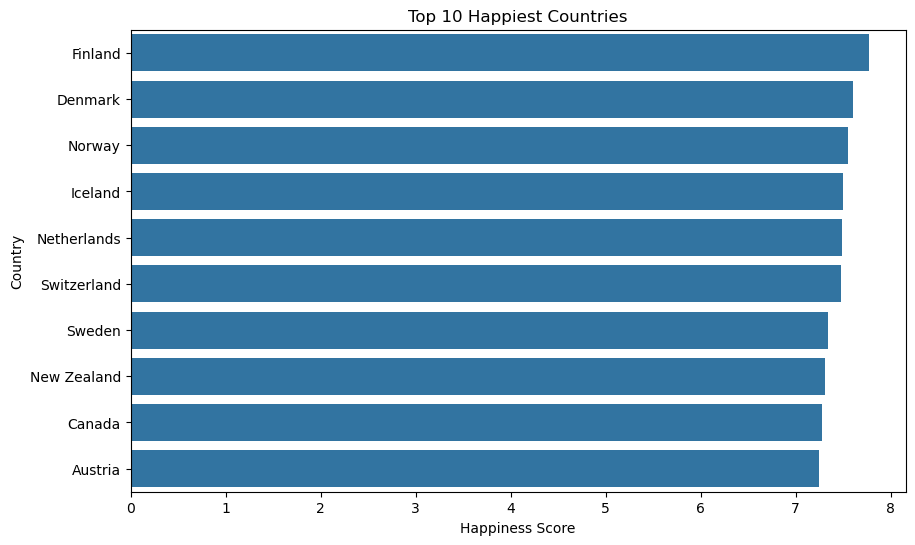

```python
# Ensure df_subset exists first
print(df_subset.head())

# Create sorted dataframe
happiness_sorted = df_subset.sort_values(by='happinessScore', ascending=False)

# Get top 10
top10 = happiness_sorted.head(10)

# Plot
import matplotlib.pyplot as plt
import seaborn as sns

plt.figure(figsize=(10,6))
sns.barplot(x='happinessScore', y='country', data=top10)

plt.title("Top 10 Happiest Countries")
plt.xlabel("Happiness Score")
plt.ylabel("Country")

plt.show()
```

### 📊 2. Histogram

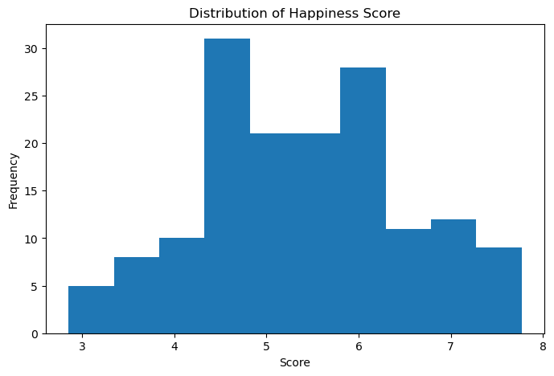

```python
plt.figure(figsize=(8,5))
plt.hist(df_subset['happinessScore'], bins=10)

plt.title("Distribution of Happiness Score")
plt.xlabel("Score")
plt.ylabel("Frequency")

plt.show()
```

### 📝 Answer:

### The distribution appears slightly skewed / approximately normal

```python
df = df_cleaned.rename(columns={"Country": "region"},inplace = True)
df_cleaned
```

|  | Overall rank | region | happinessScore | gdpPerCapita | Social support | health | freedom | Generosity | Perceptions of corruption |
| --- | --- | --- | --- | --- | --- | --- | --- | --- | --- |
| 0 | 1 | Finland | 7.769 | 1.340 | 1.587 | 0.986 | 0.596 | 0.153 | 0.393 |
| 1 | 2 | Denmark | 7.600 | 1.383 | 1.573 | 0.996 | 0.592 | 0.252 | 0.410 |
| 2 | 3 | Norway | 7.554 | 1.488 | 1.582 | 1.028 | 0.603 | 0.271 | 0.341 |
| 3 | 4 | Iceland | 7.494 | 1.380 | 1.624 | 1.026 | 0.591 | 0.354 | 0.118 |
| 4 | 5 | Netherlands | 7.488 | 1.396 | 1.522 | 0.999 | 0.557 | 0.322 | 0.298 |
| ... | ... | ... | ... | ... | ... | ... | ... | ... | ... |
| 151 | 152 | Rwanda | 3.334 | 0.359 | 0.711 | 0.614 | 0.555 | 0.217 | 0.411 |
| 152 | 153 | Tanzania | 3.231 | 0.476 | 0.885 | 0.499 | 0.417 | 0.276 | 0.147 |
| 153 | 154 | Afghanistan | 3.203 | 0.350 | 0.517 | 0.361 | 0.000 | 0.158 | 0.025 |
| 154 | 155 | Central African Republic | 3.083 | 0.026 | 0.000 | 0.105 | 0.225 | 0.235 | 0.035 |
| 155 | 156 | South Sudan | 2.853 | 0.306 | 0.575 | 0.295 | 0.010 | 0.202 | 0.091 |

156 rows × 9 columns

### 📊 3. Box Plot

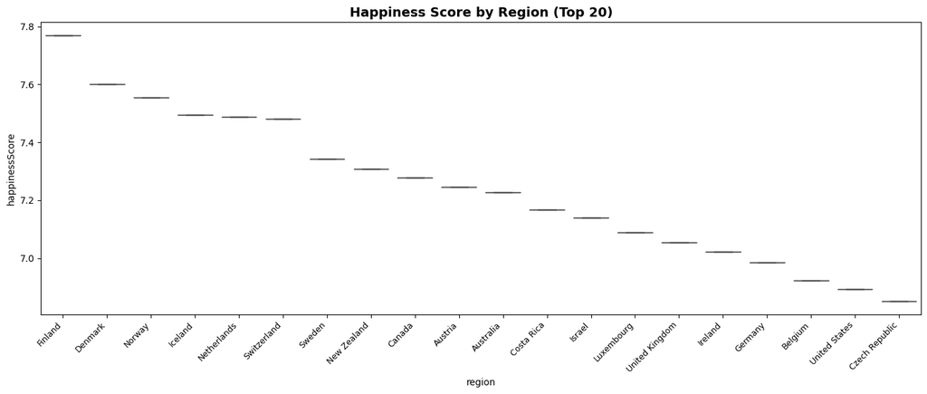

```python
top_regions = (
    df_cleaned.groupby('region')['happinessScore']
    .mean()
    .sort_values(ascending=False)
    .head(20)  # limit to top 20 for readability
    .index
)

df_plot = df_cleaned[df_cleaned['region'].isin(top_regions)]

plt.figure(figsize=(14, 6))
sns.boxplot(x='region', y='happinessScore', data=df_plot, order=top_regions)
plt.xticks(rotation=45, ha='right', fontsize=9)
plt.title("Happiness Score by Region (Top 20)", fontsize=14, fontweight='bold')
plt.tight_layout()
plt.show()
```

### 📝 Answers:

### Region with highest median: Finland

### Outliers: No

```python
df_cleaned.groupby('region')['happinessScore'].median().idxmax()
```

```
'Finland'
```

### 📊 4. Scatter Plot (GDP vs Happiness)

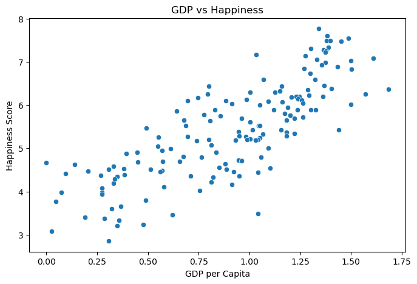

```python
plt.figure(figsize=(8,5))
sns.scatterplot(x='gdpPerCapita', y='happinessScore', data=df_subset)

plt.title("GDP vs Happiness")
plt.xlabel("GDP per Capita")
plt.ylabel("Happiness Score")

plt.show()
```

### 📝 Answer:

### There is a positive relationship between GDP and happiness

### 📊 5. Scatter Plot (Freedom vs Happiness)

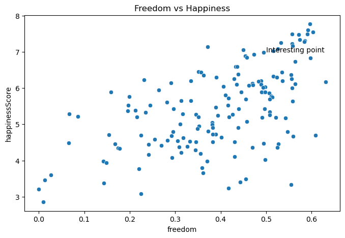

```python
plt.figure(figsize=(8,5))
sns.scatterplot(x='freedom', y='happinessScore', data=df_subset)

plt.title("Freedom vs Happiness")

plt.annotate("Interesting point", (0.5, 7))

plt.show()
```

### 🔷 PART G: INTERPRETATION

#### The visualizations revealed clear patterns. A positive relationship exists between GDP per capita and happiness score, indicating that economic strength contributes to overall well-being. Additionally, freedom also shows a meaningful association with happiness, reinforcing the importance of personal autonomy in quality of life.

#### One key insight is that happiness is multi-dimensional; while wealth plays a significant role, factors such as health, freedom, and social support are equally influential in shaping global happiness levels.